# Lesson 3: Multiple linear regression and interactions

Last updated in March 2022

## Goals for today

- Understanding the concept of multiple linear regression
- Building and interpreting multiple linear regression in R
- Using and interpreting interactions

## Multiple linear regression

- More than one predictor term
- Simple linear regression: \(Y = \alpha + \beta*X + \epsilon\)
- Multiple linear regression: \(Y = \beta_0 + \beta_1*X_1 + + \beta_2*X_2 + ... + \epsilon\)

## Multiple = more predictor terms

Note, more predictor terms does not necessarily mean more predictor variables!

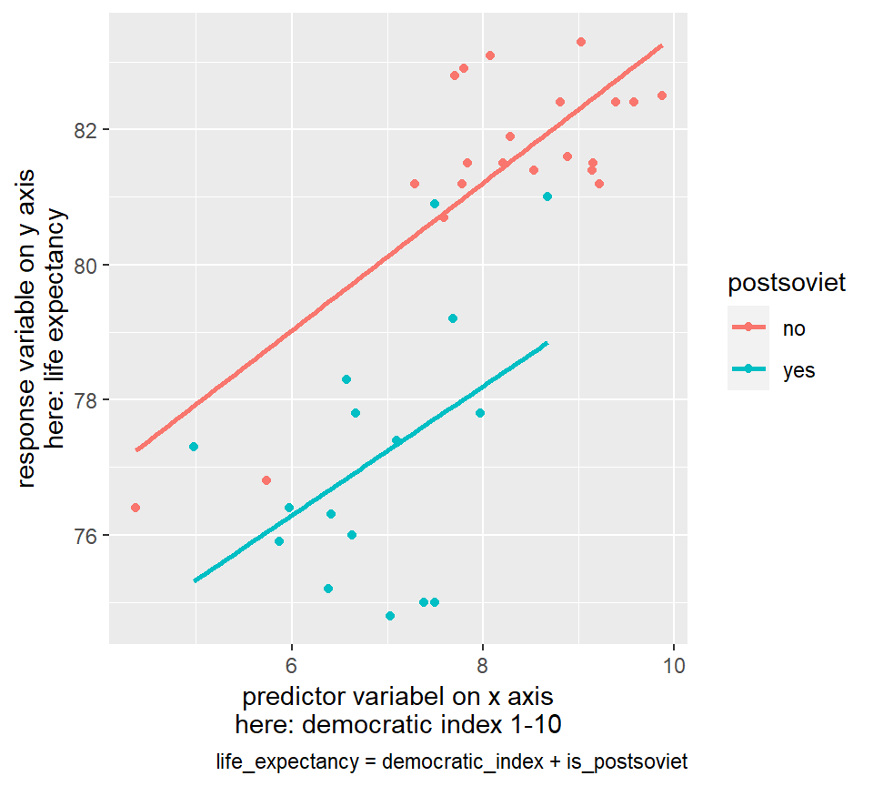

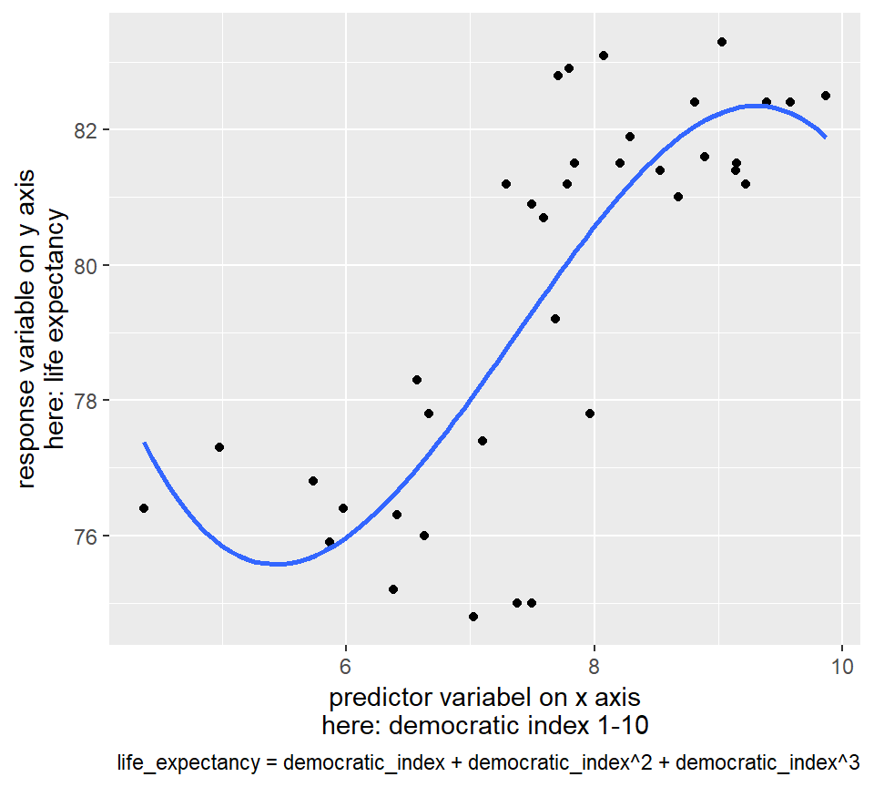

## Multiple regression: estimating more complex structures of relationships

- Descriptive modeling: See effects of individual variables net of the effects of other variables in the model (AKA „when all the other variables are held constant")
- Predictive modeling: Improve prediction, more variables = more information on the entry = usually better predictions (but risk of overfitting!)
- Modeling for causal inference: adjusting for background variables based on theory, discovering potentially spurious relationships, isolating potentially causal effects

## Interpreting coefficients in multivariate regression

- “The coefficient \(\beta_k\) is the average or expected difference in outcome \(y_k\), comparing two people who differ by one unit in the predictor \(x_k\) while being equal in all the other predictors. This is sometimes stated in shorthand as comparing two people (or, more generally, two observational units) that differ in \(x_k\) with all the other predictors held constant” (Gelman et al., 2020, p. 131)

## MLR coefficients as conditional (or additional)

- Conditional effect: contingent on the other variables in the model
- Additional effect: each coefficient represents additional effect of adding the variable in the model (all the other variables in the model are already accounted for)

## Difference-based vs. change-based interpretations

- Difference-based: “how the outcome variable differs, on average, when comparing two groups of items that differ by 1 in the relevant predictor while being identical in all the other predictors”
- Change-based: “the coefficient is the expected change in y caused by adding 1 to the relevant predictor” (i.e. changes within individuals, rather than comparisons between individuals)

## Difference-based interpretation is more cautious

To be on the save side, interpret regression coefficients as comparisons between units, not about changes within units, unless you specifically claim causality.

## Main effects and interactions

- Two kinds of main effects
  - bivariate association (simple regression) or
  - conditional/additional effects (multiple regression)
  - main effects in equation: \(... + \beta_i*X_i +...\)
- Interactions: the effect of one independent variable on the dependent variable varies across levels of another independent variable. Interaction effects as “it depends” effects.
  - e.g. interaction between smoking and inhaling asbestos in their effect on lung cancer risk
  - interactions in equation: \(... + \beta_1*X_1 + \beta_2*X_2 + \beta_3*X_1*X_2 + ...\)

## Model with interactions vs. two separate models

For an interaction of continuous variable with a binary variable, we could also run two separate models. So why not? - one model with interaction term = one fit - one model with interaction term = statistical significance test of the difference of slopes

## Interpreting interaction coefficients

This can be tricky, we will go through it in the lab part of this session. Also see (Gelman et al., 2020, pp. 134–136) for general comments and (Gelman et al., 2020, pp. 185–187) for the effect of centering variables in models with interactions.

## References

Gelman, A., Hill, J., & Vehtari, A. (2020). *Regression and other stories*. Cambridge University Press. https://doi.org/10.1017/9781139161879